# Dataset Presentation

## Distribution of Change in White Share of City Population

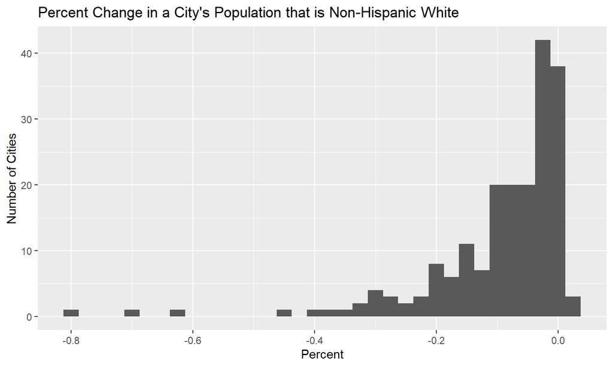

## Descriptive Statistics for the Main Variables

Summary:

```
##     firstyr     white_initial       white_2010       change_white
##  Min.   :1963   Min.   :0.04959   Min.   :0.04586   Min.   :-0.80338
##  1st Qu.:1992   1st Qu.:0.54160   1st Qu.:0.41693   1st Qu.:-0.12774
##  Median :1999   Median :0.71593   Median :0.62360   Median :-0.05761
##  Mean   :1997   Mean   :0.68604   Mean   :0.59185   Mean   :-0.09325
##  3rd Qu.:2006   3rd Qu.:0.87430   3rd Qu.:0.79109   3rd Qu.:-0.01637
##  Max.   :2010   Max.   :0.99328   Max.   :0.97721   Max.   : 0.02104
##                 NA's   :4         NA's   :1         NA's   :4
```

## Median for the Main Variables

Median of the datasets:

```
##                       Variable Median.of.the.Data
## 1    First Year of FHA Lawsuit           1999.000
## 2 White Share at First Lawsuit              0.716
## 3          White Share in 2010              0.624
## 4        Change in White Share             -0.058
```

## The Paper

- The paper using this data set is Jessica Trounstine’s “The Geography of Inequality: How Land Use Regulation Produces Segregation”
- This paper was motivated by the research linking residential zoning and segregation.
- The author used the onset of Fair Housing Lawsuits a natural experiment to test the relationship
- IV: Whether or not a city has an FHA lawsuit and the year
- DV: share of the white population in 2010
- The research question asks what the relationship is between the a city’s strictness of land use and level of segregation.
- The paper finds about a five percent reduction in the city’s percentage of whiteness, relative to cities thad did not experience an FHA lawsuit

## Extension

- How did metropolitan white share change as a result of changes in local land use resulting from FHA lawsuits?
- Do nonwhite property owners support stringent land use?
  - It appears that the research paper omits homeownership land-use preferences by race.
  - A major component of the argument of the paper is that homeowners seek to defend against reductions in property value by keeping housing scarce.
- I would like additional literature on how other planning entities mediate the changes in the share of white population
  - states, through direct preemption, and RIGOs through services, normative framing, and agenda setting may influence zoning patterns